# 福州大学数学与统计学院

## 2025-2026 学年第 2 学期《数据分析与可视化》期末考试答题模板

- 考试时间：2026年06月24日 14:00-17:30
- 考试地点：旗山东2-102
- 考试人数：44 人

> 文件命名建议：`学号_姓名_期末考试.ipynb`

请在提交前从头到尾顺序运行一次 Notebook，确认所有代码无报错，图表和结果完整显示。

## 教师评分区

> 本区域由教师评分时填写，学生不要删除。

| 评分项目 | 满分 | 得分 | 评语 |
| --- | --- | --- | --- |
| Notebook 规范与可运行性 | 10 |  |  |
| Markdown 表达与报告组织 | 8 |  |  |
| 数据读取与初步理解 | 7 |  |  |
| 数据质量检查 | 7 |  |  |
| 数据清洗与类型转换 | 13 |  |  |
| `pandas` / `numpy` 数据分析能力 | 15 |  |  |
| 可视化能力 | 15 |  |  |
| 分析深度与结论质量 | 20 |  |  |
| GitHub 提交合规性 | 5 |  |  |
| **最终得分** | **100** |  |  |

## 学生信息

- 专业：经济统计学
- 学号：152403118
- 姓名：陈欣雨
- GitHub 仓库链接：https://github.com/FZU-Data-Analysis-and-Visualization/join-github-classroom-Xinny-chen
- 数据文件：`ershoufang_list.csv`

# 福州二手房数据分析

## 1. 摘要

本报告使用`ershoufang_list.csv`中的福州二手房挂牌数据，对房源数量分布、价格水平、户型结构、房龄差异以及面积和总价之间的关系进行了分析。分析过程中，我先读取并理解数据字段，再检查缺失值、重复值和异常值，接着从`面积`、`总价`、`均价`、`时间`、`楼层`、`户型`等原始文本字段中提取出可计算的数值变量。之后使用`pandas`和`numpy`做描述性统计、分组统计、透视表和相关性分析，并用柱状图、直方图、散点图、箱线图和热力图进行可视化。结果显示，样本房源主要集中在晋安和仓山两个区域，两区合计约占70%；鼓楼、晋安、台江的单价水平相对较高；福州二手房总价中位数约为173万元，面积中位数约为93平方米；3室户型是最主要的房源类型；面积和总价呈比较明显的正相关关系，但不同区域之间的单价差异会影响同面积房源的总价表现。

## 2. 数据读取与分析目标

本次分析的数据文件为 `ershoufang_list.csv`，内容是福州二手房挂牌信息。数据中有地区、户型、面积、楼层、建造时间、所属小区、二手二手总价和均价等价格信息。由于原始字段中有不少内容带有单位或混合文本，例如 `103㎡`、`199万`、`19321元/㎡`、`中层(共31层)`，所以不能只看现成数值列，还需要从文本字段中重新提取变量。

本次主要回答以下几个问题：

1. 福州二手房房源主要集中在哪些市区？
2. 不同市区的单价和总价水平有什么差异？
3. 房源的户型、面积、房龄和楼层结构有什么特点？
4. 面积、总价、均价等数值变量之间是否存在关系？
5. 从这些统计结果中，可以得到哪些比较可靠的结论？

```python
# 导入常用库
from pathlib import Path
import warnings
warnings.filterwarnings('ignore')

import numpy as np
import pandas as pd
import matplotlib.pyplot as plt
import seaborn as sns
from matplotlib import font_manager
from IPython.display import display

# 表格显示设置
pd.set_option('display.max_columns', 60)
pd.set_option('display.width', 120)
pd.set_option('display.float_format', lambda x: f'{x:,.2f}') #采用统一格式展示价格

# 设置中文字体，避免图表中文乱码
available_fonts = [f.name for f in font_manager.fontManager.ttflist]
font_list = ['Microsoft YaHei', 'SimHei', 'Noto Sans CJK JP', 'Arial Unicode MS', 'DejaVu Sans']
for font in font_list:
    if font in available_fonts:
        plt.rcParams['font.sans-serif'] = [font]
        break

plt.rcParams['axes.unicode_minus'] = False
plt.rcParams['figure.dpi'] = 120
sns.set_theme(style='whitegrid', font=plt.rcParams['font.sans-serif'][0])
sns.set_palette('Set2')
```

```python
# 读取数据。如果出现编码问题，可以尝试 encoding='utf-8-sig' 或 encoding='gbk'
file_path = Path('ershoufang_list.csv')

if not file_path.exists():
    raise FileNotFoundError('没有找到 ershoufang_list.csv，请确认数据文件和 Notebook 放在同一个文件夹中。')

encoding_list = ['utf-8', 'utf-8-sig', 'gbk', 'gb18030']
last_error = None

for encoding_name in encoding_list:
    try:
        df = pd.read_csv(file_path, encoding=encoding_name)
        print('成功读取数据，使用编码：', encoding_name)
        break
    except Exception as error:
        last_error = error
else:
    raise last_error

print('数据文件路径：', file_path)
print('数据规模：', df.shape[0], '行，', df.shape[1], '列')
display(df.head())
```

```
成功读取数据，使用编码： utf-8
数据文件路径： ershoufang_list.csv
数据规模： 11856 行， 18 列
```

|  | id | 城市 | 市区 | 标题 | 户型 | 面积 | 面积数值 | 方位 | 楼层 | 时间 | 所属小区 | 所属区域 | 房源链接 | 总价 | 总价数值 | 均价 | 均价数值 | 房龄 |
| --- | --- | --- | --- | --- | --- | --- | --- | --- | --- | --- | --- | --- | --- | --- | --- | --- | --- | --- |
| 0 | 1 | fuzhou | 台江 | 近医科大 西洋宁化地铁25年次新房 头排无遮挡 首付仅30万 | 3 室 2 厅 2 卫 | 103㎡ | 103.00 | 南北 | 中层(共31层) | 2025年建造 | 榕发望熙雅筑B区 | 台江 万宝 交通西路 | https://fz.anjuke.com/prop/view/S4605513392729... | 199万 | 199.00 | 19321元/㎡ | 19,321.00 | 2年内 |
| 1 | 2 | fuzhou | 晋安 | 来电可大刀 建发望樾盘精装3房 地铁口 低密宜居 精装好房 | 3 室 2 厅 2 卫 | 83㎡ | 83.00 | 南北 | 低层(共18层) | 2025年建造 | 国贸保利和颂锦原 | 晋安 五四北 坂中路 | https://fz.anjuke.com/prop/view/S4248588093856... | 181万 | 181.00 | 21808元/㎡ | 21,808.00 | 2年内 |
| 2 | 3 | fuzhou | 晋安 | 锦鸿佳园，五里亭地铁口，电梯高层，精装拎包入住，周边配套成熟 | 3 室 2 厅 1 卫 | 90㎡ | 90.00 | 南北 | 高层(共33层) | 2024年建造 | 锦鸿佳园 | 晋安 福马路 七贤路2号 | https://fz.anjuke.com/prop/view/S4537384389565... | 159万 | 159.00 | 17667元/㎡ | 17,667.00 | 2年内 |
| 3 | 4 | fuzhou | 鼓楼 | 湖滨小隔壁十八中临近西次湖新房地铁4号线 | 3 室 2 厅 1 卫 | 90㎡ | 90.00 | 南北 | 低层(共7层) | 2025年建造 | 凯佳湖岸公馆 | 鼓楼 东街 湖头街 | https://fz.anjuke.com/prop/view/S4514662328474... | 300万 | 300.00 | 33334元/㎡ | 33,334.00 | 2年内 |
| 4 | 5 | fuzhou | 晋安 | 保利招商和樾风华 3室2厅2卫 | 3 室 2 厅 2 卫 | 107㎡ | 107.00 | 南北 | 低层(共18层) | 2024年建造 | 保利招商和樾风华 | 晋安 王庄 连洋西路 | https://fz.anjuke.com/prop/view/S4201934614372... | 330万 | 330.00 | 30842元/㎡ | 30,842.00 | 2年内 |

## 3. 数据基本情况

本小节用于展示数据规模、字段名称、数据类型和样例，以及对数据的初步分析。

```python
#3.1 数据规模
df.shape
```

```
(11856, 18)
```

```python
#3.2 字段名称
pd.DataFrame({'字段名': df.columns})
```

|  | 字段名 |
| --- | --- |
| 0 | id |
| 1 | 城市 |
| 2 | 市区 |
| 3 | 标题 |
| 4 | 户型 |
| 5 | 面积 |
| 6 | 面积数值 |
| 7 | 方位 |
| 8 | 楼层 |
| 9 | 时间 |
| 10 | 所属小区 |
| 11 | 所属区域 |
| 12 | 房源链接 |
| 13 | 总价 |
| 14 | 总价数值 |
| 15 | 均价 |
| 16 | 均价数值 |
| 17 | 房龄 |

```python
#3.3 字段与数据类型
df.info()
```

```
<class 'pandas.DataFrame'>
RangeIndex: 11856 entries, 0 to 11855
Data columns (total 18 columns):
 #   Column  Non-Null Count  Dtype
---  ------  --------------  -----
 0   id      11856 non-null  int64
 1   城市      11856 non-null  str
 2   市区      11856 non-null  str
 3   标题      11856 non-null  str
 4   户型      11856 non-null  str
 5   面积      11856 non-null  str
 6   面积数值    11856 non-null  float64
 7   方位      11856 non-null  str
 8   楼层      11856 non-null  str
 9   时间      11856 non-null  str
 10  所属小区    11856 non-null  str
 11  所属区域    11856 non-null  str
 12  房源链接    11856 non-null  str
 13  总价      11830 non-null  str
 14  总价数值    11830 non-null  float64
 15  均价      11830 non-null  str
 16  均价数值    11830 non-null  float64
 17  房龄      11856 non-null  str
dtypes: float64(3), int64(1), str(14)
memory usage: 1.6 MB
```

```python
#3.4 数据前5行样例
display(df.head())
```

|  | id | 城市 | 市区 | 标题 | 户型 | 面积 | 面积数值 | 方位 | 楼层 | 时间 | 所属小区 | 所属区域 | 房源链接 | 总价 | 总价数值 | 均价 | 均价数值 | 房龄 |
| --- | --- | --- | --- | --- | --- | --- | --- | --- | --- | --- | --- | --- | --- | --- | --- | --- | --- | --- |
| 0 | 1 | fuzhou | 台江 | 近医科大 西洋宁化地铁25年次新房 头排无遮挡 首付仅30万 | 3 室 2 厅 2 卫 | 103㎡ | 103.00 | 南北 | 中层(共31层) | 2025年建造 | 榕发望熙雅筑B区 | 台江 万宝 交通西路 | https://fz.anjuke.com/prop/view/S4605513392729... | 199万 | 199.00 | 19321元/㎡ | 19,321.00 | 2年内 |
| 1 | 2 | fuzhou | 晋安 | 来电可大刀 建发望樾盘精装3房 地铁口 低密宜居 精装好房 | 3 室 2 厅 2 卫 | 83㎡ | 83.00 | 南北 | 低层(共18层) | 2025年建造 | 国贸保利和颂锦原 | 晋安 五四北 坂中路 | https://fz.anjuke.com/prop/view/S4248588093856... | 181万 | 181.00 | 21808元/㎡ | 21,808.00 | 2年内 |
| 2 | 3 | fuzhou | 晋安 | 锦鸿佳园，五里亭地铁口，电梯高层，精装拎包入住，周边配套成熟 | 3 室 2 厅 1 卫 | 90㎡ | 90.00 | 南北 | 高层(共33层) | 2024年建造 | 锦鸿佳园 | 晋安 福马路 七贤路2号 | https://fz.anjuke.com/prop/view/S4537384389565... | 159万 | 159.00 | 17667元/㎡ | 17,667.00 | 2年内 |
| 3 | 4 | fuzhou | 鼓楼 | 湖滨小隔壁十八中临近西次湖新房地铁4号线 | 3 室 2 厅 1 卫 | 90㎡ | 90.00 | 南北 | 低层(共7层) | 2025年建造 | 凯佳湖岸公馆 | 鼓楼 东街 湖头街 | https://fz.anjuke.com/prop/view/S4514662328474... | 300万 | 300.00 | 33334元/㎡ | 33,334.00 | 2年内 |
| 4 | 5 | fuzhou | 晋安 | 保利招商和樾风华 3室2厅2卫 | 3 室 2 厅 2 卫 | 107㎡ | 107.00 | 南北 | 低层(共18层) | 2024年建造 | 保利招商和樾风华 | 晋安 王庄 连洋西路 | https://fz.anjuke.com/prop/view/S4201934614372... | 330万 | 330.00 | 30842元/㎡ | 30,842.00 | 2年内 |

```python
#3.5.1数值变量描述性统计

number_columns = ['面积数值', '总价数值', '均价数值']

number_describe = df[number_columns].describe().T
number_describe = number_describe.rename(columns={
    'count': '非空数量',
    'mean': '平均值',
    'std': '标准差',
    'min': '最小值',
    '25%': '下四分位数',
    '50%': '中位数',
    '75%': '上四分位数',
    'max': '最大值'
})

display(number_describe.round(2))
```

|  | 非空数量 | 平均值 | 标准差 | 最小值 | 下四分位数 | 中位数 | 上四分位数 | 最大值 |
| --- | --- | --- | --- | --- | --- | --- | --- | --- |
| 面积数值 | 11,856.00 | 97.89 | 25.92 | 18.00 | 84.73 | 93.00 | 113.01 | 500.00 |
| 总价数值 | 11,830.00 | 190.76 | 111.17 | 16.80 | 130.00 | 173.00 | 225.00 | 3,180.00 |
| 均价数值 | 11,830.00 | 19,235.60 | 6,925.95 | 2,169.00 | 15,298.25 | 18,325.50 | 22,268.50 | 92,968.00 |

从描述性统计可以看出，面积数值的中位数为93平方米，平均值为97.89平方米，说明大多数房源面积集中在90平方米左右，但也存在少量面积较大的房源。总价数值的中位数为173万元，平均值为190.76万元，平均值高于中位数，说明总价分布受到部分高总价房源的影响。均价数值的中位数为18325.50元/平方米，平均值为19235.60元/平方米，同样说明样本中存在部分单价较高的房源。

```python
#3.5.2 类别变量描述性统计

category_columns = ['城市', '市区', '户型', '方位', '楼层', '房龄']

category_describe = df[category_columns].describe().T
category_describe = category_describe.rename(columns={
    'count': '非空数量',
    'unique': '不同取值数量',
    'top': '出现最多的取值',
    'freq': '最高频次'
})

display(category_describe)
```

|  | 非空数量 | 不同取值数量 | 出现最多的取值 | 最高频次 |
| --- | --- | --- | --- | --- |
| 城市 | 11856 | 1 | fuzhou | 11856 |
| 市区 | 11856 | 12 | 晋安 | 4350 |
| 户型 | 11856 | 56 | 3 室 2 厅 2 卫 | 4964 |
| 方位 | 11856 | 10 | 南北 | 7381 |
| 楼层 | 11856 | 139 | 高层(共33层) | 257 |
| 房龄 | 11856 | 4 | 10年以上 | 3055 |

从类别变量的描述性统计结果来看，本数据中的房源全部来自福州，因此`城市`字段只有1个取值。`市区`字段共有 12个不同取值，说明数据覆盖了福州市的12个区，其中晋安区房源数量最多，共4350条，说明样本中晋安区房源占比较高。`户型`字段共有56种不同取值，其中出现最多的是`3室2厅2卫`，共有4964条，说明三室两厅类房源是样本中的主要户型。`方位`字段共有10种取值，其中`南北`朝向最多，共7381条，说明南北朝向在二手房市场中较为常见。`楼层`字段的不同取值较多，共有139种，说明房源楼层信息比较分散；`房龄`字段共有4类，其中 `10年以上` 出现最多，共 3055 条，说明样本中老房源占有一定比例。

**数据的初步分析小结：**

通过前面的查看可以看出，本数据集共有11856条记录、18个字段，主要包括地区信息、房屋属性、价格信息和房源说明信息，字段内容比较完整，能够支持后续对福州二手房市场进行分析。其中`总价`和`均价`存在少量缺失，价格分布也可能受到部分高价房源影响。

总体来看，数据具有较好的分析基础，但在正式分析前仍需要对缺失值、重复值、异常值以及文本字段中的数值信息进行进一步检查和处理，以保证后续统计分析和可视化结果更加可靠。

## 4. 数据质量检查

这一部分主要检查缺失值、重复值、异常值和格式不统一等问题。数据质量检查不是为了把所有看起来特殊的值都删除，而是先判断这些问题会不会影响后面的分析。

```python
# 4.1 缺失值检查
missing_table = pd.DataFrame({
    '缺失数量': df.isna().sum(),
    '缺失比例': (df.isna().mean() * 100).round(2).astype(str) + '%'
}).sort_values('缺失数量', ascending=False)

display(missing_table)
```

|  | 缺失数量 | 缺失比例 |
| --- | --- | --- |
| 均价 | 26 | 0.22% |
| 总价数值 | 26 | 0.22% |
| 均价数值 | 26 | 0.22% |
| 总价 | 26 | 0.22% |
| 城市 | 0 | 0.0% |
| id | 0 | 0.0% |
| 市区 | 0 | 0.0% |
| 标题 | 0 | 0.0% |
| 户型 | 0 | 0.0% |
| 面积 | 0 | 0.0% |
| 时间 | 0 | 0.0% |
| 楼层 | 0 | 0.0% |
| 方位 | 0 | 0.0% |
| 面积数值 | 0 | 0.0% |
| 房源链接 | 0 | 0.0% |
| 所属区域 | 0 | 0.0% |
| 所属小区 | 0 | 0.0% |
| 房龄 | 0 | 0.0% |

```python
# 4.2 重复值检查
full_duplicate_count = df.duplicated().sum()
id_duplicate_count = df.duplicated(subset=['id']).sum()
link_duplicate_count = df.duplicated(subset=['房源链接']).sum()
title_duplicate_count = df.duplicated(subset=['标题']).sum()

repeat_table = pd.DataFrame({
    '检查项目': ['完全重复行', 'id 重复', '房源链接重复', '标题重复'],
    '重复数量': [full_duplicate_count, id_duplicate_count, link_duplicate_count, title_duplicate_count]
})

display(repeat_table)
```

|  | 检查项目 | 重复数量 |
| --- | --- | --- |
| 0 | 完全重复行 | 0 |
| 1 | id 重复 | 0 |
| 2 | 房源链接重复 | 0 |
| 3 | 标题重复 | 2068 |

```python
# 4.3 主要字段取值情况
for column_name in ['城市', '市区', '方位', '房龄']:
    print('\n', column_name, '字段的取值情况：')
    display(df[column_name].value_counts().head(15))
```

```
 城市 字段的取值情况：
```

```
城市
fuzhou    11856
Name: count, dtype: int64
```

```
 市区 字段的取值情况：
```

```
市区
晋安    4350
仓山    3948
鼓楼    1239
台江     906
闽侯     630
福清     219
连江     176
马尾     169
长乐     106
平潭      59
罗源      35
永泰      19
Name: count, dtype: int64
```

```
 方位 字段的取值情况：
```

```
方位
南北    7381
南     3043
东南     627
西南     400
东      227
西       75
北       28
东北      28
西北      28
东西      19
Name: count, dtype: int64
```

```
 房龄 字段的取值情况：
```

```
房龄
10年以上    3055
2-5年     3052
5-10年    3049
2年内      2700
Name: count, dtype: int64
```

```python
# 4.4 数值字段合理性检查
# 检查面积、总价、均价是否存在缺失值或小于等于0的不合理值

number_columns = ['面积数值', '总价数值', '均价数值']

range_check = pd.DataFrame({
    '小于等于0数量': (df[number_columns] <= 0).sum(),
    '最小值': df[number_columns].min(),
    '最大值': df[number_columns].max()
})

display(range_check)
```

|  | 小于等于0数量 | 最小值 | 最大值 |
| --- | --- | --- | --- |
| 面积数值 | 0 | 18.00 | 500.00 |
| 总价数值 | 0 | 16.80 | 3,180.00 |
| 均价数值 | 0 | 2,169.00 | 92,968.00 |

```python
# 4.5 使用 IQR 方法检查数值型异常值
# IQR 的思路是：低于 Q1 - 1.5IQR 或高于 Q3 + 1.5IQR 的值，先标记为可能异常值
outlier_rows = []

for column_name in ['面积数值', '总价数值', '均价数值']:
    one_column = df[column_name].dropna()
    q1 = one_column.quantile(0.25)
    q3 = one_column.quantile(0.75)
    iqr = q3 - q1
    lower_limit = q1 - 1.5 * iqr
    upper_limit = q3 + 1.5 * iqr
    outlier_count = ((one_column < lower_limit) | (one_column > upper_limit)).sum()
    outlier_rows.append([column_name, q1, q3, lower_limit, upper_limit, outlier_count])

outlier_table = pd.DataFrame(outlier_rows, columns=['字段', 'Q1', 'Q3', '下界', '上界', 'IQR异常值数量'])
display(outlier_table)
```

|  | 字段 | Q1 | Q3 | 下界 | 上界 | IQR异常值数量 |
| --- | --- | --- | --- | --- | --- | --- |
| 0 | 面积数值 | 84.73 | 113.01 | 42.31 | 155.43 | 297 |
| 1 | 总价数值 | 130.00 | 225.00 | -12.50 | 367.50 | 500 |
| 2 | 均价数值 | 15,298.25 | 22,268.50 | 4,842.88 | 32,723.88 | 528 |

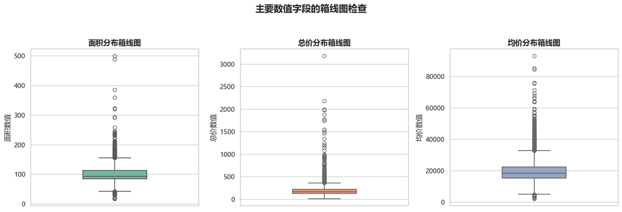

```python
# 4.6 用箱线图更直观地查看异常值
box_columns = ['面积数值', '总价数值', '均价数值']
box_titles = ['面积分布箱线图', '总价分布箱线图', '均价分布箱线图']

plt.figure(figsize=(15, 4.8))
for i, column_name in enumerate(box_columns):
    plt.subplot(1, 3, i + 1)
    sns.boxplot(y=df[column_name], color=sns.color_palette('Set2')[i], width=0.38, linewidth=1.4)
    plt.title(box_titles[i], fontsize=13, fontweight='bold')
    plt.ylabel(column_name)
    plt.xlabel('')

plt.suptitle('主要数值字段的箱线图检查', fontsize=16, fontweight='bold', y=1.05)
plt.tight_layout()
plt.show()
```

**数据质量小结：**

从检查结果看，数据整体比较完整，`总价`、`总价数值`、`均价`和`均价数值`有少量缺失，共26条记录，比例很低。数据中没有完全重复行，`id`和`房源链接`也没有重复，说明每条记录基本可以看作一条独立房源。`标题`有重复，但房源标题本身可能比较相似，不能只根据标题判断重复，所以这里不直接删除。

从箱线图和IQR结果看，面积、总价、均价都存在一些高值。结合二手房场景，这些高值很可能是大面积住宅、核心区域房源或高总价房源，不一定是错误数据。因此后续分析中保留这些记录，但在做价格比较时更多使用中位数，并在图表中注意极端值对均值的影响。

## 5. 数据清洗与字段转换

```python
# 建议先复制一份数据，避免直接破坏原始数据
data = df.copy()

# 处理文本字段的首尾空格
text_columns = data.select_dtypes(include='object').columns
for column_name in text_columns:
    data[column_name] = data[column_name].astype(str).str.strip()

# 从带单位的文本中提取数值
# 例如：103㎡ -> 103，199万 -> 199，19321元/㎡ -> 19321
data['面积_平方米'] = pd.to_numeric(data['面积'].str.extract(r'([0-9]+(?:\.[0-9]+)?)')[0], errors='coerce')
data['总价_万元'] = pd.to_numeric(data['总价'].str.extract(r'([0-9]+(?:\.[0-9]+)?)')[0], errors='coerce')
data['均价_元每平'] = pd.to_numeric(data['均价'].str.extract(r'([0-9]+(?:\.[0-9]+)?)')[0], errors='coerce')

# 从建造时间中提取年份，并计算房龄年数
data['建造年份'] = pd.to_numeric(data['时间'].str.extract(r'(\d{4})')[0], errors='coerce')
data['房龄_年'] = 2026 - data['建造年份']

# 从楼层字段中提取楼层位置和总楼层，例如：中层(共31层)
data['楼层位置'] = data['楼层'].str.extract(r'(低层|中层|高层)')[0]
data['总楼层'] = pd.to_numeric(data['楼层'].str.extract(r'共(\d+)层')[0], errors='coerce')

# 从户型中提取室、厅、卫数量，例如：3 室 2 厅 2 卫
data['室数'] = pd.to_numeric(data['户型'].str.extract(r'(\d+)\s*室')[0], errors='coerce')
data['厅数'] = pd.to_numeric(data['户型'].str.extract(r'(\d+)\s*厅')[0], errors='coerce')
data['卫数'] = pd.to_numeric(data['户型'].str.extract(r'(\d+)\s*卫')[0], errors='coerce')

# 构造一些方便分析的分类变量
data['面积段'] = pd.cut(
    data['面积_平方米'],
    bins=[0, 60, 90, 120, 150, 300, 10000],
    labels=['60㎡以下', '60-90㎡', '90-120㎡', '120-150㎡', '150-300㎡', '300㎡以上']
)

data['总价段'] = pd.cut(
    data['总价_万元'],
    bins=[0, 100, 200, 300, 500, 800, 2000, 10000],
    labels=['100万以下', '100-200万', '200-300万', '300-500万', '500-800万', '800-2000万', '2000万以上']
)

# 从标题中简单识别部分关键词，作为辅助分析变量
data['是否提到地铁'] = np.where(data['标题'].str.contains('地铁|号线|轨道', na=False), '标题提到地铁', '标题未提到地铁')
data['是否提到精装'] = np.where(data['标题'].str.contains('精装|装修|拎包', na=False), '标题提到精装', '标题未提到精装')

# 价格相关分析需要总价和均价不缺失，所以单独建立一个价格分析数据集
data_price = data.dropna(subset=['总价_万元', '均价_元每平']).copy()

print('清洗后数据规模：', data.shape)
print('价格分析数据规模：', data_price.shape)
display(data.head())
```

```
清洗后数据规模： (11856, 32)
价格分析数据规模： (11830, 32)
```

|  | id | 城市 | 市区 | 标题 | 户型 | 面积 | 面积数值 | 方位 | 楼层 | 时间 | 所属小区 | 所属区域 | 房源链接 | 总价 | 总价数值 | 均价 | 均价数值 | 房龄 | 面积_平方米 | 总价_万元 | 均价_元每平 | 建造年份 | 房龄_年 | 楼层位置 | 总楼层 | 室数 | 厅数 | 卫数 | 面积段 | … |
| --- | --- | --- | --- | --- | --- | --- | --- | --- | --- | --- | --- | --- | --- | --- | --- | --- | --- | --- | --- | --- | --- | --- | --- | --- | --- | --- | --- | --- | --- | --- |
| 0 | 1 | fuzhou | 台江 | 近医科大 西洋宁化地铁25年次新房 头排无遮挡 首付仅30万 | 3 室 2 厅 2 卫 | 103㎡ | 103.00 | 南北 | 中层(共31层) | 2025年建造 | 榕发望熙雅筑B区 | 台江 万宝 交通西路 | https://fz.anjuke.com/prop/view/S4605513392729... | 199万 | 199.00 | 19321元/㎡ | 19,321.00 | 2年内 | 103.00 | 199.00 | 19,321.00 | 2025 | 1 | 中层 | 31 | 3 | 2 | 2 | 90-120㎡ | … |
| 1 | 2 | fuzhou | 晋安 | 来电可大刀 建发望樾盘精装3房 地铁口 低密宜居 精装好房 | 3 室 2 厅 2 卫 | 83㎡ | 83.00 | 南北 | 低层(共18层) | 2025年建造 | 国贸保利和颂锦原 | 晋安 五四北 坂中路 | https://fz.anjuke.com/prop/view/S4248588093856... | 181万 | 181.00 | 21808元/㎡ | 21,808.00 | 2年内 | 83.00 | 181.00 | 21,808.00 | 2025 | 1 | 低层 | 18 | 3 | 2 | 2 | 60-90㎡ | … |
| 2 | 3 | fuzhou | 晋安 | 锦鸿佳园，五里亭地铁口，电梯高层，精装拎包入住，周边配套成熟 | 3 室 2 厅 1 卫 | 90㎡ | 90.00 | 南北 | 高层(共33层) | 2024年建造 | 锦鸿佳园 | 晋安 福马路 七贤路2号 | https://fz.anjuke.com/prop/view/S4537384389565... | 159万 | 159.00 | 17667元/㎡ | 17,667.00 | 2年内 | 90.00 | 159.00 | 17,667.00 | 2024 | 2 | 高层 | 33 | 3 | 2 | 1 | 60-90㎡ | … |
| 3 | 4 | fuzhou | 鼓楼 | 湖滨小隔壁十八中临近西次湖新房地铁4号线 | 3 室 2 厅 1 卫 | 90㎡ | 90.00 | 南北 | 低层(共7层) | 2025年建造 | 凯佳湖岸公馆 | 鼓楼 东街 湖头街 | https://fz.anjuke.com/prop/view/S4514662328474... | 300万 | 300.00 | 33334元/㎡ | 33,334.00 | 2年内 | 90.00 | 300.00 | 33,334.00 | 2025 | 1 | 低层 | 7 | 3 | 2 | 1 | 60-90㎡ | … |
| 4 | 5 | fuzhou | 晋安 | 保利招商和樾风华 3室2厅2卫 | 3 室 2 厅 2 卫 | 107㎡ | 107.00 | 南北 | 低层(共18层) | 2024年建造 | 保利招商和樾风华 | 晋安 王庄 连洋西路 | https://fz.anjuke.com/prop/view/S4201934614372... | 330万 | 330.00 | 30842元/㎡ | 30,842.00 | 2年内 | 107.00 | 330.00 | 30,842.00 | 2024 | 2 | 低层 | 18 | 3 | 2 | 2 | 90-120㎡ | … |

```python
# 检查自己从文本中提取的数值，是否和原来的数值列基本一致
check_table = pd.DataFrame({
    '面积差异最大值': [(data['面积_平方米'] - data['面积数值']).abs().max()],
    '总价差异最大值': [(data['总价_万元'] - data['总价数值']).abs().max()],
    '均价差异最大值': [(data['均价_元每平'] - data['均价数值']).abs().max()]
})

display(check_table)
```

|  | 面积差异最大值 | 总价差异最大值 | 均价差异最大值 |
| --- | --- | --- | --- |
| 0 | 0.00 | 0.00 | 0.00 |

```python
# 保存清洗后的数据，方便后面复查
clean_file = Path('ershoufang_list_cleaned.csv')
data.to_csv(clean_file, index=False, encoding='utf-8-sig')
print('清洗后的数据已保存为：', clean_file)
```

```
清洗后的数据已保存为： ershoufang_list_cleaned.csv
```

```python
# 删除价格缺失值，生成价格分析专用数据
data_price = data.dropna(subset=['总价_万元', '均价_元每平']).copy()

print('完整清洗后数据量：', len(data))
print('价格分析数据量：', len(data_price))
```

```
完整清洗后数据量： 11856
价格分析数据量： 11830
```

**数据清洗与字段转换说明：**

在本小节中，我主要对数据做了以下四类处理：

1. **处理文本字段格式**

   对所有文本字段去掉首尾空格，防止同一类别因为空格不同而被识别成不同取值。
2. **提取价格和面积中的数值信息**

   从 `面积`、`总价` 和 `均价` 中提取数值，得到 `面积_平方米`、`总价_万元`、`均价_元每平`，方便后续进行统计分析和可视化。
3. **提取房屋属性变量**

   从 `时间`、`楼层`、`户型` 中提取 `建造年份`、`房龄_年`、`楼层位置`、`总楼层`、`室数`、`厅数`、`卫数` 等变量，使原本的文本信息可以用于分组统计。
4. **构造辅助分析变量**

   根据面积和总价划分区间，同时从标题中识别“地铁”“精装”等关键词，用来进行简单对比分析。

对于价格缺失的26条记录，没有直接从整体数据里删除。因为这部分缺失数量在11856条数据中占比较小，而且这些房源在市区、户型、面积等非价格分析中仍然有用。但在涉及总价和均价的分析时，我使用 `data_price`，也就是删除价格缺失后的数据。这样既保留了更多原始样本，也避免了价格缺失对统计结果产生影响。

## 6. 描述性统计分析

这一部分使用 `pandas` 和 `numpy` 进行统计分析，包括总体描述、分组统计、排序、透视表和相关性分析。

```python
# 6.1 整体价格和面积水平
summary_overall = pd.DataFrame({
    '指标': [
        '原始房源数量',
        '有效价格房源数量',
        '总价均值(万元)',
        '总价中位数(万元)',
        '均价均值(元/㎡)',
        '均价中位数(元/㎡)',
        '面积均值(㎡)',
        '面积中位数(㎡)'
    ],
    '数值': [
        len(data),
        len(data_price),
        data_price['总价_万元'].mean(),
        data_price['总价_万元'].median(),
        data_price['均价_元每平'].mean(),
        data_price['均价_元每平'].median(),
        data['面积_平方米'].mean(),
        data['面积_平方米'].median()
    ]
})

display(summary_overall.round(2))
```

|  | 指标 | 数值 |
| --- | --- | --- |
| 0 | 原始房源数量 | 11,856.00 |
| 1 | 有效价格房源数量 | 11,830.00 |
| 2 | 总价均值(万元) | 190.76 |
| 3 | 总价中位数(万元) | 173.00 |
| 4 | 均价均值(元/㎡) | 19,235.60 |
| 5 | 均价中位数(元/㎡) | 18,325.50 |
| 6 | 面积均值(㎡) | 97.89 |
| 7 | 面积中位数(㎡) | 93.00 |

此处的价格均值是除以11830，因为有前面分析可知，价格缺失26条信息，但缺失信息的房源的面积、户型等非价格信息有价值，故未删除这些房源，在涉及价格方面的分析使用删除价格后的数据。

```python
# 6.2 不同市区的房源数量、总价和均价
city_summary = (
    data_price
    .groupby('市区')
    .agg(
        房源数量=('id', 'count'),
        总价中位数=('总价_万元', 'median'),
        均价中位数=('均价_元每平', 'median'),
        面积中位数=('面积_平方米', 'median')
    )
    .sort_values('房源数量', ascending=False)
)

city_summary['房源占比'] = city_summary['房源数量'] / city_summary['房源数量'].sum()
display(city_summary.round(2))
```

| 市区 | 房源数量 | 总价中位数 | 均价中位数 | 面积中位数 | 房源占比 |
| --- | --- | --- | --- | --- | --- |
| 晋安 | 4346 | 187.00 | 20,000.00 | 91.13 | 0.37 |
| 仓山 | 3926 | 173.00 | 17,613.50 | 97.00 | 0.33 |
| 鼓楼 | 1239 | 195.00 | 22,973.00 | 90.00 | 0.10 |
| 台江 | 906 | 175.00 | 19,763.50 | 89.73 | 0.08 |
| 闽侯 | 630 | 110.00 | 12,844.50 | 89.00 | 0.05 |
| 福清 | 219 | 138.00 | 11,819.00 | 118.15 | 0.02 |
| 连江 | 176 | 147.50 | 13,445.00 | 107.00 | 0.01 |
| 马尾 | 169 | 128.00 | 13,072.00 | 101.00 | 0.01 |
| 长乐 | 106 | 126.00 | 11,736.50 | 105.00 | 0.01 |
| 平潭 | 59 | 128.00 | 10,948.00 | 120.45 | 0.00 |
| 罗源 | 35 | 59.00 | 5,103.00 | 116.68 | 0.00 |
| 永泰 | 19 | 75.00 | 7,143.00 | 105.00 | 0.00 |

```python
# 6.3 房源室数维度统计

room_summary = (
    data_price
    .groupby('室数')
    .agg(
        房源数量=('id', 'count'),
        总价中位数=('总价_万元', 'median'),
        均价中位数=('均价_元每平', 'median'),
        面积中位数=('面积_平方米', 'median')
    )
    .sort_index()
)

display(room_summary.round(2))
```

| 室数 | 房源数量 | 总价中位数 | 均价中位数 | 面积中位数 |
| --- | --- | --- | --- | --- |
| 1 | 303 | 85.00 | 19,556.00 | 45.00 |
| 2 | 1945 | 131.00 | 18,400.00 | 73.01 |
| 3 | 7183 | 175.00 | 17,768.00 | 92.73 |
| 4 | 2288 | 240.00 | 20,591.00 | 124.00 |
| 5 | 85 | 275.00 | 21,349.00 | 136.13 |
| 6 | 19 | 300.00 | 18,625.00 | 196.00 |
| 7 | 5 | 510.00 | 35,092.00 | 200.00 |
| 8 | 2 | 2,465.00 | 59,035.00 | 410.64 |

```python
# 6.4 房龄维度统计
age_order = ['2年内', '2-5年', '5-10年', '10年以上']

age_summary = (
    data_price
    .groupby('房龄')
    .agg(
        房源数量=('id', 'count'),
        总价中位数=('总价_万元', 'median'),
        均价中位数=('均价_元每平', 'median'),
        面积中位数=('面积_平方米', 'median')
    )
    .reindex(age_order)
)

display(age_summary.round(2))
```

| 房龄 | 房源数量 | 总价中位数 | 均价中位数 | 面积中位数 |
| --- | --- | --- | --- | --- |
| 2年内 | 2683 | 134.00 | 15,773.00 | 90.00 |
| 2-5年 | 3043 | 178.00 | 18,953.00 | 90.00 |
| 5-10年 | 3049 | 176.00 | 18,477.00 | 93.33 |
| 10年以上 | 3055 | 180.00 | 18,667.00 | 95.60 |

```python
# 6.5 不同市区、不同房龄下的均价中位数
price_pivot = pd.pivot_table(
    data_price,
    values='均价_元每平',
    index='市区',
    columns='房龄',
    aggfunc='median'
)

# 按整体均价中位数排序，方便观察
city_order = city_summary.sort_values('均价中位数', ascending=False).index
price_pivot = price_pivot.loc[city_order]
display(price_pivot.round(0))
```

| 房龄 市区 | 10年以上 | 2-5年 | 2年内 | 5-10年 |
| --- | --- | --- | --- | --- |
| 鼓楼 | 21,834.00 | 29,602.00 | 32,925.00 | 24,337.00 |
| 晋安 | 18,436.00 | 20,668.00 | 19,663.00 | 20,376.00 |
| 台江 | 18,254.00 | 20,545.00 | 19,167.00 | 20,314.00 |
| 仓山 | 17,960.00 | 17,749.00 | 16,522.00 | 17,526.00 |
| 连江 | 10,310.00 | 14,504.00 | 13,033.00 | 15,193.00 |
| 马尾 | 11,432.00 | 12,834.00 | 12,120.00 | 15,132.00 |
| 闽侯 | 11,436.00 | 13,969.00 | 6,574.00 | 15,318.00 |
| 福清 | 7,202.00 | 15,636.00 | 8,858.00 | 15,565.00 |
| 长乐 | 7,593.00 | 11,019.00 | 10,387.00 | 15,802.00 |
| 平潭 | 9,994.00 | 12,964.00 | 11,040.00 | 7,406.00 |
| 永泰 | 4,580.00 | 7,186.00 | 7,429.00 | 5,338.00 |
| 罗源 | 4,720.00 | 3,796.00 | 6,194.00 | 4,394.00 |

```python
# 6.6 面积、总价、均价等变量之间的相关性
corr_columns = ['面积_平方米', '总价_万元', '均价_元每平', '房龄_年', '总楼层', '室数', '厅数', '卫数']
corr_table = data_price[corr_columns].corr()
display(corr_table.round(3))
```

|  | 面积_平方米 | 总价_万元 | 均价_元每平 | 房龄_年 | 总楼层 | 室数 | 厅数 | 卫数 |
| --- | --- | --- | --- | --- | --- | --- | --- | --- |
| 面积_平方米 | 1.00 | 0.64 | 0.14 | -0.03 | -0.01 | 0.77 | 0.43 | 0.66 |
| 总价_万元 | 0.64 | 1.00 | 0.79 | 0.02 | -0.00 | 0.45 | 0.20 | 0.41 |
| 均价_元每平 | 0.14 | 0.79 | 1.00 | 0.10 | -0.01 | 0.08 | -0.03 | 0.07 |
| 房龄_年 | -0.03 | 0.02 | 0.10 | 1.00 | -0.30 | -0.09 | -0.05 | -0.20 |
| 总楼层 | -0.01 | -0.00 | -0.01 | -0.30 | 1.00 | -0.09 | -0.01 | -0.05 |
| 室数 | 0.77 | 0.45 | 0.08 | -0.09 | -0.09 | 1.00 | 0.47 | 0.64 |
| 厅数 | 0.43 | 0.20 | -0.03 | -0.05 | -0.01 | 0.47 | 1.00 | 0.40 |
| 卫数 | 0.66 | 0.41 | 0.07 | -0.20 | -0.05 | 0.64 | 0.40 | 1.00 |

**描述性统计结果小结：**

从总体统计看，本数据集中二手房总价中位数约为173万元，面积中位数约为93平方米，均价中位数约为18326元/㎡。从市区看，晋安和仓山的房源数量最多，合计接近全部样本的70%，说明样本中的挂牌房源主要集中在这两个区域。价格方面，鼓楼的均价中位数最高，其次是晋安、台江和仓山，这和市中心资源、区位条件可能有关。

从户型看，3室房源数量最多，是样本中的主力户型；4室房源的总价和面积明显更高。相关性表显示，面积和总价之间相关性较明显，说明面积越大总价通常越高；总价和均价的相关性也较高，说明区域价格水平会对总价产生比较直接的影响。

## 7. 可视化分析

在后续分析中，不涉及价格的图表继续使用完整清洗后的数据；涉及总价和均价的价格类分析，则使用删除价格缺失值后的`data_price`数据。这样既能保留更多房源信息，也能避免价格缺失影响统计结果。

### 图表 1：不同市区的房源数量对比

图1研究福州二手房挂牌房源主要集中在哪些市区这个问题

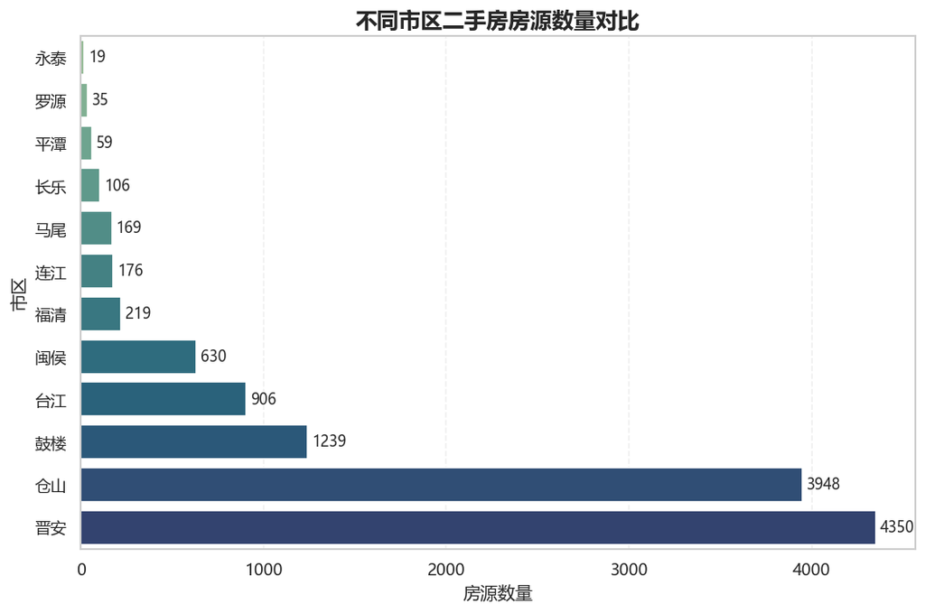

```python
# 统计各市区房源数量
city_count = data['市区'].value_counts().sort_values()

plt.figure(figsize=(9, 6))
ax = sns.barplot(x=city_count.values, y=city_count.index, hue=city_count.index, palette='crest', legend=False)

plt.title('不同市区二手房房源数量对比', fontsize=15, fontweight='bold')
plt.xlabel('房源数量')
plt.ylabel('市区')
plt.grid(axis='x', linestyle='--', alpha=0.3)

for i, value in enumerate(city_count.values):
    ax.text(value + 25, i, int(value), va='center', fontsize=10)

plt.tight_layout()
plt.show()
```

**由图表1可知：**  
从图中可以看出，晋安和仓山的房源数量明显多于其他市区，其中晋安有4350套，仓山有3948套，两者合计约占全部房源的70%。这说明本数据集中的福州二手房供应主要集中在晋安和仓山。鼓楼、台江虽然房源数量少一些，但属于核心城区，后面仍需要重点关注其价格水平。

### 图表 2：不同市区的均价中位数对比

图2研究不同市区的单价水平是否存在明显差异。这里使用中位数，是为了减少极端高价房源对结果的影响。

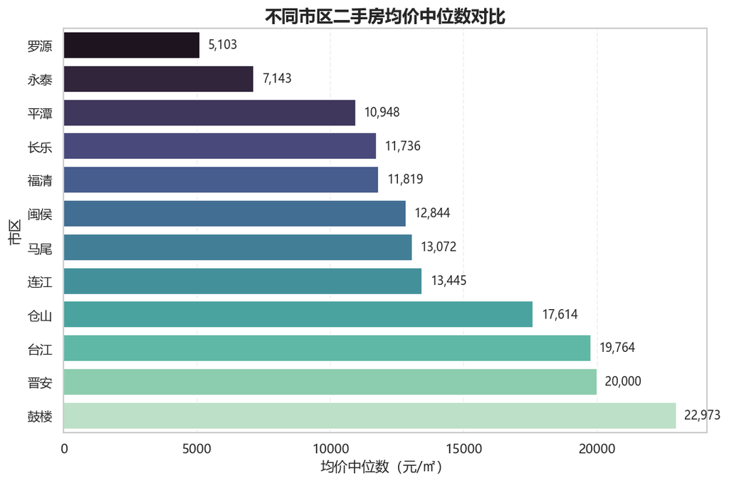

```python
# 各市区均价中位数
city_price = city_summary.sort_values('均价中位数', ascending=True)

plt.figure(figsize=(9, 6))
city_price_plot = city_price.reset_index()
ax = sns.barplot(data=city_price_plot, x='均价中位数', y='市区', hue='市区', palette='mako', legend=False)

plt.title('不同市区二手房均价中位数对比', fontsize=15, fontweight='bold')
plt.xlabel('均价中位数（元/㎡）')
plt.ylabel('市区')
plt.grid(axis='x', linestyle='--', alpha=0.3)

for i, value in enumerate(city_price['均价中位数']):
    ax.text(value + 300, i, f'{value:,.0f}', va='center', fontsize=10)

plt.tight_layout()
plt.show()
```

**由图表2可知：**  
鼓楼的均价中位数最高，约为 22973 元/㎡；晋安、台江也处在较高水平，均价中位数接近或超过 19000 元/㎡。相比之下，罗源、永泰等区域的单价明显较低。这个结果说明福州二手房市场存在比较明显的区域差异，核心城区和热门区域的单位面积价格更高。

### 图表 3：二手房总价分布

图3研究多数二手房的总价大概集中在哪个范围这个问题。

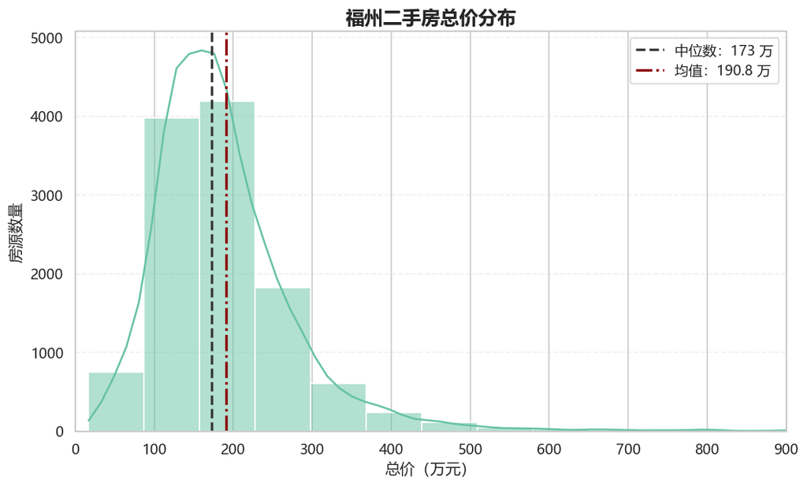

```python
# 总价分布图
median_total_price = data_price['总价_万元'].median()
mean_total_price = data_price['总价_万元'].mean()

plt.figure(figsize=(9, 5.5))
sns.histplot(data_price['总价_万元'], bins=45, kde=True, color=sns.color_palette('Set2')[0])
plt.axvline(median_total_price, color='#3A3A3A', linestyle='--', linewidth=2, label=f'中位数：{median_total_price:.0f} 万')
plt.axvline(mean_total_price, color='#8B0000', linestyle='-.', linewidth=2, label=f'均值：{mean_total_price:.1f} 万')

plt.title('福州二手房总价分布', fontsize=15, fontweight='bold')
plt.xlabel('总价（万元）')
plt.ylabel('房源数量')
plt.xlim(0, 900)
plt.legend()
plt.grid(axis='y', linestyle='--', alpha=0.3)
plt.tight_layout()
plt.show()
```

**由图表3可知：**  
福州二手房总价主要集中在 100 万到 300 万之间，总价中位数约为 173 万元，均值约为 190.76 万元。均值高于中位数，说明数据中存在少量高总价房源，把平均值向上拉高。因此，在描述普通房源价格水平时，中位数比均值更稳健。

### 图表 4：面积与总价之间的关系

这个图想看的是：房屋面积变大时，总价是否也会提高，同时观察不同市区之间是否有差异。

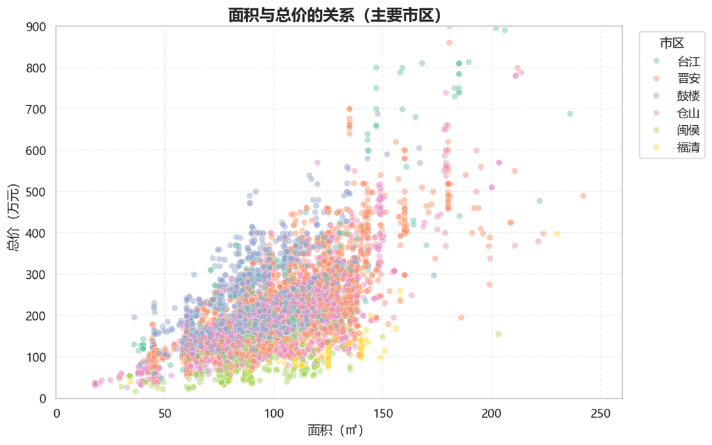

```
面积与总价的相关系数为： 0.643
```

```python
# 选取房源数量较多的 6 个市区，避免图例过于拥挤
top_city_list = data_price['市区'].value_counts().head(6).index
scatter_data = data_price[data_price['市区'].isin(top_city_list)].copy()

plt.figure(figsize=(9.5, 6))
sns.scatterplot(
    data=scatter_data,
    x='面积_平方米',
    y='总价_万元',
    hue='市区',
    alpha=0.45,
    s=35,
    palette='Set2'
)

plt.title('面积与总价的关系（主要市区）', fontsize=15, fontweight='bold')
plt.xlabel('面积（㎡）')
plt.ylabel('总价（万元）')
plt.xlim(0, 260)
plt.ylim(0, 900)
plt.legend(title='市区', bbox_to_anchor=(1.02, 1), loc='upper left')
plt.grid(True, linestyle='--', alpha=0.3)
plt.tight_layout()
plt.show()

# 计算面积与总价的相关系数
area_price_corr = data_price[['面积_平方米', '总价_万元']].corr().loc['面积_平方米', '总价_万元']
print('面积与总价的相关系数为：', round(area_price_corr, 3))
```

**由图表4可知：**  
整体来看，面积与总价存在正相关的关系，面积越大的房源，总价通常也越高，说明面积是影响总价的重要因素。不过，同样面积的房源在不同市区之间总价并不完全相同，核心区域的点往往会更靠上。这说明二手房总价不仅受面积影响，也受到市区位置和单价水平影响。

### 图表 5：不同室数户型的房源数量和总价中位数

图5主要研究主流户型、以及户型与总价的关系。

[figure not shown]

```python
# 为了图表稳定，只看样本数量不少于 30 的室数
room_plot = room_summary.reset_index()

plt.figure(figsize=(8.5, 5.5))
ax1 = sns.barplot(data=room_plot, x='室数', y='房源数量', color=sns.color_palette('Set2')[1], alpha=0.75)
plt.title('不同室数户型的房源数量与总价中位数', fontsize=15, fontweight='bold')
plt.xlabel('室数')
plt.ylabel('房源数量')
plt.grid(axis='y', linestyle='--', alpha=0.3)

ax2 = ax1.twinx()
sns.lineplot(data=room_plot, x='室数', y='总价中位数', marker='o', linewidth=2.5, color='#2F4F4F', ax=ax2)
ax2.set_ylabel('总价中位数（万元）')

for i, row in room_plot.iterrows():
    ax1.text(i, row['房源数量'] + 80, int(row['房源数量']), ha='center', fontsize=9)
    ax2.text(i, row['总价中位数'] + 8, f"{row['总价中位数']:.0f}", ha='center', fontsize=9, color='#2F4F4F')

plt.tight_layout()
plt.show()
```

**由图表5可知：**  
3室房源数量最多，是样本中的主力户型；2室和4室也有一定数量。随着室数增加，总价中位数整体呈上升趋势，其中4室、5室房源的总价中位数明显高于2室、3室。这比较符合实际情况，因为室数多通常对应更大的面积和更高的总价。

### 图表6：不同市区与房龄组合下的均价热力图

这个图想进一步看：房龄和市区同时变化时，均价中位数有什么差异。

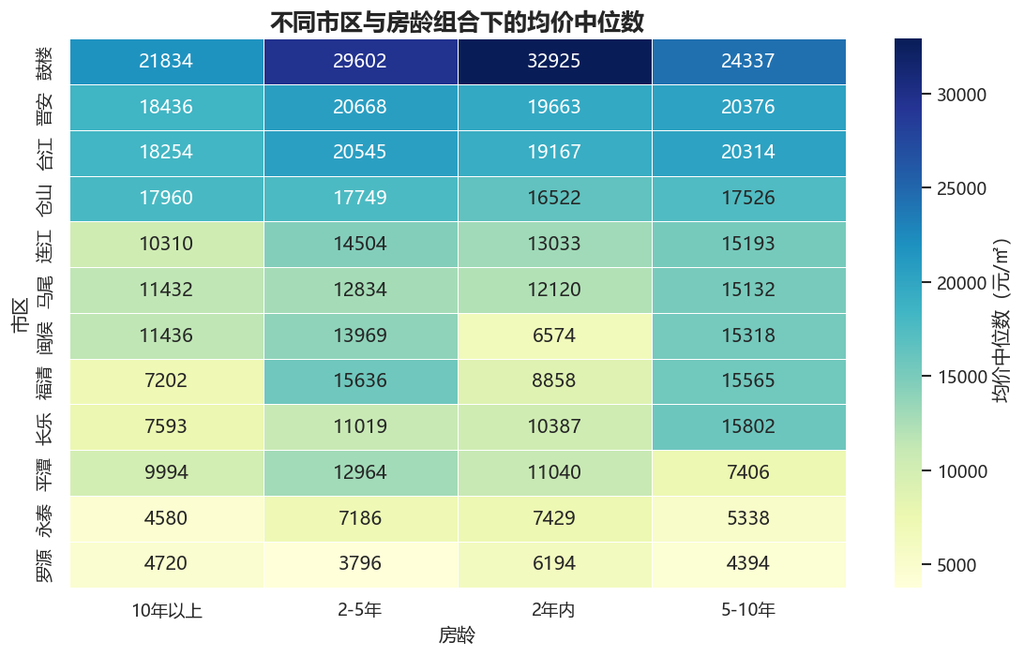

```python
plt.figure(figsize=(9.5, 6))
sns.heatmap(
    price_pivot,
    annot=True,
    fmt='.0f',
    cmap='YlGnBu',
    linewidths=0.5,
    cbar_kws={'label': '均价中位数（元/㎡）'}
)

plt.title('不同市区与房龄组合下的均价中位数', fontsize=15, fontweight='bold')
plt.xlabel('房龄')
plt.ylabel('市区')
plt.tight_layout()
plt.show()
```

**由图表6可知 ：**  
热力图显示，市区差异比单纯房龄差异更明显。鼓楼、晋安、台江在多个房龄类别下都保持较高单价，而闽侯、罗源、永泰等区域整体单价较低。这个结果说明，解释福州二手房价格时，区域位置是很重要的因素，单独看房龄容易忽略区域差异。

## 8. 主要结论

**数据局限：**  
本数据是挂牌数据，不一定等同于最终成交数据；标题中的“地铁”“精装”等关键词也只是从文本中简单识别，不能完全代表真实条件。另外，不同市区样本量差异较大，小样本区域的均价结果需要谨慎解释。总体来说，本次分析可以较好地反映样本中福州二手房挂牌市场的基本结构和价格特征。